# UNICEF Global Infant Mortality Report

# GLOBAL INFANT MORTALITY

“The infant mortality rate refers to the probability of dying between birth and exactly 1 year of age, expressed per 1,000 live births. These deaths are a product of the limited access many children and communities have to basic yet lifesaving health interventions such as vaccination, infectious disease treatments, adequate nutrition and clean water and sanitation… More than 80 percent of newborn deaths are due to prematurity, complications during birth or infections such as pneumonia and sepsis…

“For children everywhere, the most risky period of life is the first month. In 2017, 2.5 million newborns died in their first month. A baby born in sub-Saharan Africa or in Southern Asia was nine times more likely to die in the first month than a baby born in a high-income country…” (UNICEF, 2019).

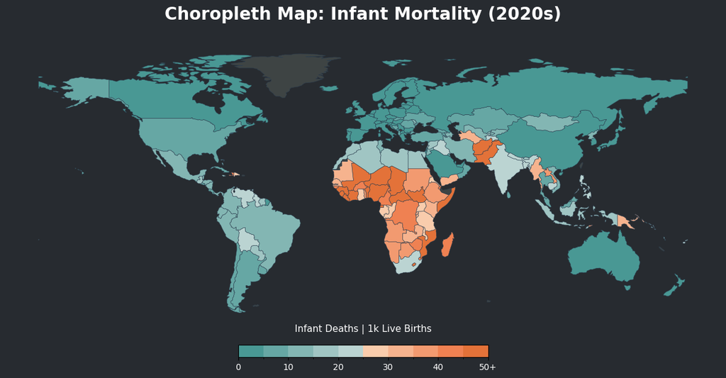

Figure 1: Global Infant Mortality Rates (2020s)

```python
# 1. INSTALL THE TOOLS

import pandas as pd
import geopandas as gpd
import matplotlib.pyplot as plt
import matplotlib.colors as mcolors

# 2. LOAD DATA
df = pd.read_csv('unicef_indicator_2.csv')

# 3. FILTER: Only "Total" Sex + Latest record from 2020s
df_filtered = df[df['sex'] == 'Total']

df_latest = (df_filtered[df_filtered['time_period'] >= 2020]
             .sort_values('time_period')
             .drop_duplicates('alpha_3_code', keep='last'))

# 4. GEOMETRY
world_url = "https://raw.githubusercontent.com/datasets/geo-boundaries-world-110m/master/countries.geojson"
world = gpd.read_file(world_url)
world = world[world['iso_a3'] != 'ATA']

# 5. MERGE
map_data = world.merge(df_latest, left_on='iso_a3', right_on='alpha_3_code', how='left')

# 6. 10-STEP COLOR PARAMETERS
colors = [
    "#499894", "#66A7A4", "#83B6B3", "#A0C5C3", "#BBD4D2",
    "#F9CCAC", "#F6B38E", "#F29A70", "#EF8152", "#E37239"
]
cmap = mcolors.ListedColormap(colors)
# Last bound is 200 to catch all outliers; we will label this point as '50+'
bounds = [0, 5, 10, 15, 20, 25, 30, 35, 40, 45, 200]
norm = mcolors.BoundaryNorm(bounds, cmap.N)

# 7. VIZ: Optimized for Slate Theme
fig, ax = plt.subplots(1, 1, figsize=(15, 8), facecolor='#272b30')
ax.set_facecolor('#272b30')

map_data.plot(column='obs_value',
              ax=ax,
              cmap=cmap,
              norm=norm,
              legend=True,
              legend_kwds={'orientation': "horizontal",
                           'pad': 0.05,
                           'shrink': 0.35}, # Adjusted from 0.6 to 0.35 to match bar chart scale
              missing_kwds={'color': '#3e4444'},
              edgecolor='#2c3e50',
              linewidth=0.4)

# LEGEND CORRECTIONS
cbar = fig.axes[1]
cbar.set_title("Infant Deaths | 1k Live Births", color='white', fontsize=11, pad=15)

# Setting ticks at the actual boundary values
cbar.set_xticks([0, 10, 20, 30, 40, 200])
cbar.set_xticklabels(["0", "10", "20", "30", "40", "50+"], color='white')

plt.title("Choropleth Map: Infant Mortality (2020s)", color='white', fontsize=20, fontweight='bold', pad=25)
plt.axis('off')

plt.show()
```

# HIGHEST to LOWEST

“Global deaths of newborn babies remain alarmingly high, particularly among the world’s poorest countries. Babies born in Japan, Iceland and Singapore have the best chance at survival, while newborns in Pakistan, the Central African Republic and Afghanistan face the worst odds…

“In high income countries, that rate is 3 deaths per 1,000 [and in] low income countries, the average newborn mortality rate is 27 deaths per 1,000 births. Newborns from the riskiest places to give birth are up to 50 times more likely to die than those from the safest… More than 80 percent of these deaths can be prevented with access to well-trained midwives, along with proven solutions like clean water, disinfectants, breastfeeding within the first hour, skin-to-skin contact and good nutrition” (UNICEF, 2018).

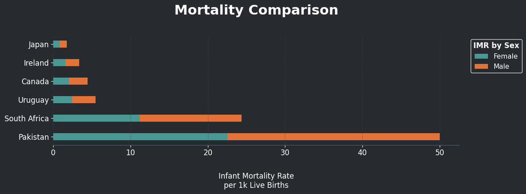

Figure 2: Mortality Comparison: Male vs Female (2020s)

```python
import pandas as pd
import matplotlib.pyplot as plt

# 1. PREP DATA
df = pd.read_csv('unicef_indicator_2.csv')

# Use the latest available year in the 2020s
latest_year = df[df['time_period'] >= 2020]['time_period'].max()

# Exact order from your Tableau viz (Top to Bottom: Japan -> Pakistan)
# Note: barh plots from bottom-to-top, so we list them in reverse here
target_order = [
    'Pakistan',
    'South Africa',
    'Uruguay',
    'Canada',
    'Ireland',
    'Japan'
]

# Filter for the target countries and separate gender rows (excluding 'Total')
df_viz = df[
    (df['country'].isin(target_order)) &
    (df['time_period'] == latest_year) &
    (df['sex'] != 'Total')
].copy()

# 2. ADJUST VALUES FOR STACKING (Rate per 1,000)
# Dividing by 2 ensures the total bar length reflects the actual IMR per 1k
df_viz['obs_value_adj'] = df_viz['obs_value'] / 2

# Pivot for stacking
pivot_df = df_viz.pivot(index='country', columns='sex', values='obs_value_adj')

# Re-apply the specific order
pivot_df = pivot_df.reindex(target_order)

# 3. VIZ: Stacked Bar Chart (Slate Theme)
# Height is reduced to 4.5 to pack the country labels closer together
fig, ax = plt.subplots(figsize=(12, 4.5), facecolor='#272b30')
ax.set_facecolor('#272b30')

# Colors: Dark Teal for Female, Orange for Male
colors = {'Female': '#499894', 'Male': '#E37239'}

# width=0.375 provides the 250% thickness increase while maintaining separation
pivot_df.plot(kind='barh', stacked=True, color=[colors['Female'], colors['Male']], ax=ax, width=0.375)

# 4. STYLING (Updated X-axis padding only)
plt.title("Mortality Comparison", color='white', fontsize=22, fontweight='bold', pad=35)

# Increased labelpad to 25 to push the title further below the axis numbers
ax.set_xlabel("Infant Mortality Rate\nper 1k Live Births",
              color='white',
              fontsize=12,
              labelpad=25)

# Removed label and kept Y-axis clean as requested
ax.set_ylabel("")

# Formatting ticks and grid
ax.tick_params(colors='white', labelsize=12)
ax.grid(axis='x', color='#3e4444', linestyle='--', alpha=0.5)

# Clean borders
for spine in ax.spines.values():
    spine.set_visible(False)
ax.spines['bottom'].set_visible(True)
ax.spines['bottom'].set_color('#4e5d6c')

# Legend with updated title
legend = plt.legend(title="IMR by Sex", bbox_to_anchor=(1.02, 1.0), loc='upper left',
                    facecolor='#272b30', edgecolor='white', labelcolor='white', fontsize=11)
plt.setp(legend.get_title(), color='white', fontsize=12, fontweight='bold')

plt.tight_layout()
plt.show()
```

# EARNED INCOME vs. ECONOMIC ACTIVITY

“Every year, the World Bank assigns each country to an income group based on its gross national income (GNI) per capita. GNI per capita is a measure of the average income of a country’s residents, including income that is earned abroad. It is often used as a proxy for a country’s level of economic development… Although infant mortality has decreased significantly over the past few decades, its relationship with economic inequality remains significant” (Government of Canada, 2004).

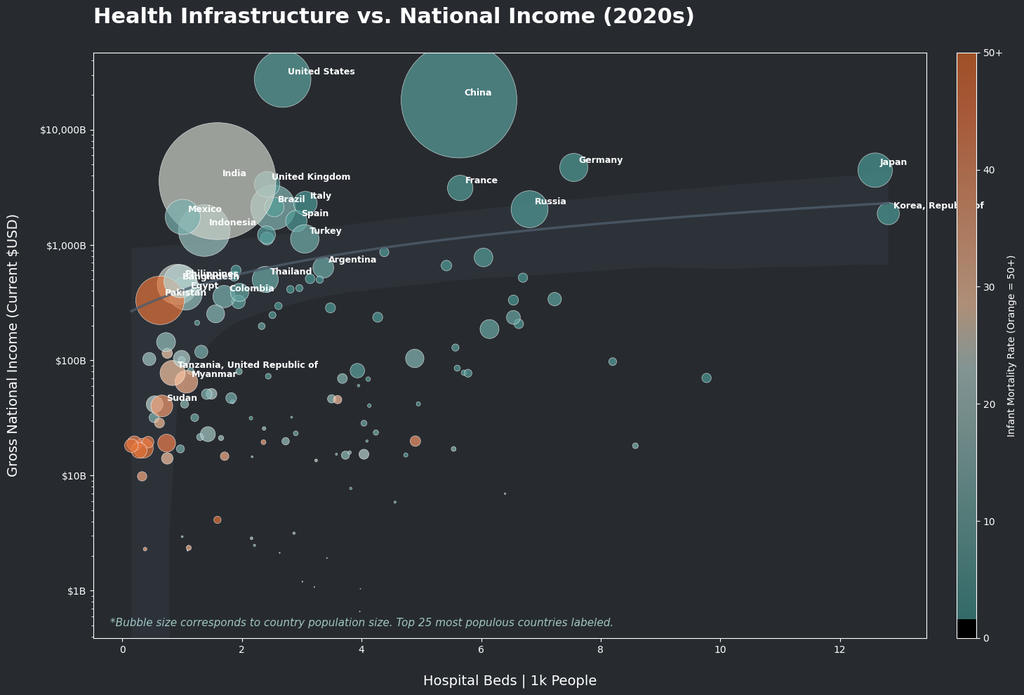

```python
import pandas as pd
import matplotlib.pyplot as plt
import seaborn as sns
from matplotlib.colors import LinearSegmentedColormap
import matplotlib.ticker as ticker

# 1. LOAD THE COMBINED DATA
df = pd.read_csv('unicef_combined_data.csv')

# 2. FILTER FOR 2020s AND LATEST DATA
df_2020s = df[(df['time_period'] >= 2020) & (df['sex'] == 'Total')].copy()
latest = df_2020s.sort_values('time_period').groupby('alpha_3_code').last().reset_index()

# 3. PREP METRICS
x_col = 'Hospital beds (per 1,000 people)'
y_col = 'GNI (current US$)'
pop_col = 'Population, total'
latest['imr_capped'] = latest['obs_value'].clip(upper=50)

# Filter out rows with missing vital data
plot_df = latest.dropna(subset=[x_col, y_col, pop_col]).copy()

# 4. STYLING & COLORS
plt.style.use('dark_background')
fig, ax = plt.subplots(figsize=(16, 10), facecolor='#272b30')
ax.set_facecolor('#272b30')

# Colors: Dark Teal (#499894) to Orange (#E37239)
map_colors = ["#499894", "#66A7A4", "#83B6B3", "#A0C5C3", "#BBD4D2",
              "#F9CCAC", "#F6B38E", "#F29A70", "#EF8152", "#E37239"]
custom_cmap = LinearSegmentedColormap.from_list("MapSync", map_colors)

# 5. REGRESSION LINE (Muted Slate: #4e5d6c)
sns.regplot(
    data=plot_df, x=x_col, y=y_col, scatter=False,
    line_kws={'color': '#4e5d6c', 'linewidth': 2.5, 'alpha': 0.8}, ax=ax
)

# 6. BUBBLE PLOT
scatter = ax.scatter(
    plot_df[x_col], plot_df[y_col],
    s=plot_df[pop_col] / 1_000_000 * 10,
    c=plot_df['imr_capped'], cmap=custom_cmap,
    alpha=0.7, edgecolors='white', linewidth=0.5
)

# 7. ADD COUNTRY LABELS (Top 25 by Population)
top_populous = plot_df.nlargest(25, pop_col)
for i, row in top_populous.iterrows():
    ax.annotate(row['country'], (row[x_col], row[y_col]), xytext=(5, 5),
                textcoords='offset points', fontsize=9, color='white', fontweight='bold')

# 8. AXIS & FORMATTING
ax.set_yscale('log')
ax.yaxis.set_major_formatter(ticker.FuncFormatter(lambda x, p: f'${x/1e9:,.0f}B' if x >= 1e9 else f'${x/1e6:,.0f}M'))

plt.title("Health Infrastructure vs. National Income (2020s)",
          color='white', fontsize=22, fontweight='bold', loc='left', pad=30)

# Added labelpad=20 to increase space between labels and markers
plt.xlabel("Hospital Beds | 1k People", color='white', fontsize=14, labelpad=20)
plt.ylabel("Gross National Income (Current $USD)", color='white', fontsize=14, labelpad=20)

# 9. LEGEND & FOOTNOTE
cbar = plt.colorbar(scatter, ax=ax, pad=0.03, aspect=30)
cbar.set_label('Infant Mortality Rate (Orange = 50+)', color='white')
cbar.set_ticks([0, 10, 20, 30, 40, 50])
cbar.ax.set_yticklabels(['0', '10', '20', '30', '40', '50+'])

plt.annotate("*Bubble size corresponds to country population size. Top 25 most populous countries labeled.",
             xy=(0.02, 0.02), xycoords='axes fraction', color='#A0C5C3', fontsize=11, style='italic')

plt.tight_layout()
plt.show()
```

# HEALTH ≠ WEALTH

“While national income (GNI) is a strong predictor of child survival, it is not a guarantee. Some low-income countries have achieved remarkable progress in reducing infant mortality through targeted health policies and infrastructure, while some middle-income countries continue to struggle. This demonstrates that political will and efficient allocation of resources toward healthcare can be as critical as overall economic wealth in determining the life expectancy of the most vulnerable populations” (Rohenkohl et al., 2025).

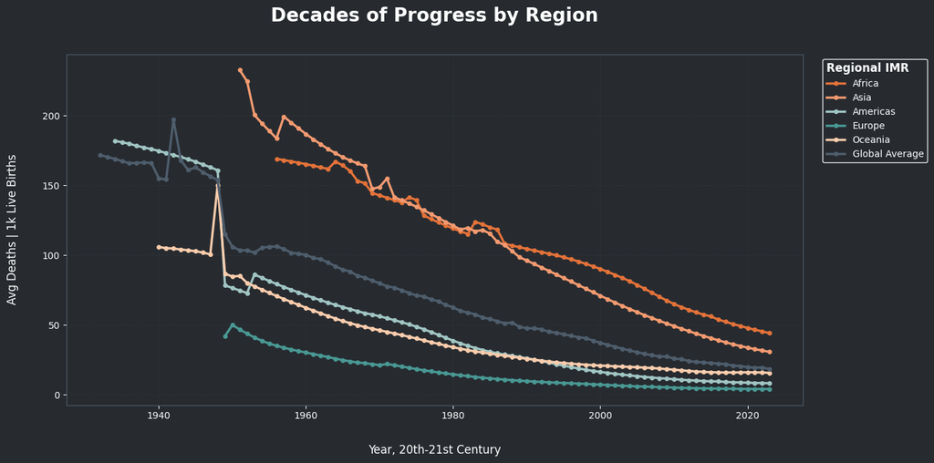

```python
import pandas as pd
import matplotlib.pyplot as plt

# 1. LOAD UNICEF DATA
df = pd.read_csv('unicef_indicator_2.csv')
df_filtered = df[df['sex'] == 'Total'].copy()

# 2. LOCAL REGION MAPPING (Ensuring lines represent major regions)
region_map = {
    'AFG': 'Asia', 'IND': 'Asia', 'CHN': 'Asia', 'PAK': 'Asia', 'BGD': 'Asia',
    'NGA': 'Africa', 'ETH': 'Africa', 'COD': 'Africa', 'ZAF': 'Africa', 'SLE': 'Africa',
    'USA': 'Americas', 'BRA': 'Americas', 'MEX': 'Americas', 'CAN': 'Americas', 'ARG': 'Americas',
    'GBR': 'Europe', 'FRA': 'Europe', 'DEU': 'Europe', 'ITA': 'Europe', 'UKR': 'Europe',
    'AUS': 'Oceania', 'NZL': 'Oceania', 'PNG': 'Oceania', 'FJI': 'Oceania'
}

# Apply the mapping
df_filtered['region'] = df_filtered['alpha_3_code'].map(region_map)
df_filtered['region'] = df_filtered['region'].fillna('Global Average')

# 3. AGGREGATE
regional_trends = df_filtered.groupby(['region', 'time_period'])['obs_value'].mean().reset_index()

# 4. VIZ: Time-Series (Slate Theme)
fig, ax = plt.subplots(figsize=(14, 7), facecolor='#272b30')
ax.set_facecolor('#272b30')

# Updated Theme Colors with Cream for Oceania
region_colors = {
    'Africa': '#E37239',   # Orange
    'Asia': '#F29A70',     # Peach
    'Americas': '#A0C5C3', # Light Teal
    'Europe': '#499894',   # Dark Teal
    'Oceania': '#F9CCAC',  # Cream (re-introduced for contrast)
    'Global Average': '#4e5d6c' # Muted Slate
}

for region in ['Africa', 'Asia', 'Americas', 'Europe', 'Oceania', 'Global Average']:
    data = regional_trends[regional_trends['region'] == region]
    if not data.empty:
        plt.plot(data['time_period'], data['obs_value'],
                 marker='o', markersize=4, linewidth=2.5,
                 label=region, color=region_colors.get(region, '#ffffff'))

# 5. STYLING (Updated with increased padding for legibility)
plt.title("Decades of Progress by Region",
          color='white', fontsize=20, fontweight='bold', pad=35) # Increased title pad

# Added labelpad=25 to push X-axis title lower
ax.set_xlabel("Year, 20th-21st Century",
              color='white', fontsize=12, labelpad=25)

# Added labelpad=25 to push Y-axis title further to the left
ax.set_ylabel("Avg Deaths | 1k Live Births",
              color='white', fontsize=12, labelpad=25)

ax.grid(color='#3e4444', linestyle='--', alpha=0.3)
ax.tick_params(colors='white', labelsize=10)

# Legend
legend = plt.legend(facecolor='#272b30', edgecolor='white',
                    labelcolor='white', framealpha=0.9,
                    bbox_to_anchor=(1.02, 1), loc='upper left') # Moved outside to avoid overlap

legend.set_title("Regional IMR", prop={'size': 12, 'weight': 'bold'})
plt.setp(legend.get_title(), color='white')

# Add a small pad between the legend title and the labels
legend._legend_box.align = "left"

# Clean borders
for spine in ax.spines.values():
    spine.set_color('#4e5d6c')

plt.tight_layout()
plt.show()
```

# REFERENCES

Government of Canada (2004). Notes on health indicators. https://www150.statcan.gc.ca/n1/pub/82-221-x/2004001/4062774-eng.htm (20-Mar-26).

Rohenkohl B, et al. (2025). The health and wealth of nations. https://ourworldindata.org/grapher/child-mortality-vs-gdp-per-capita (20-Mar-26).

UNICEF (2018). Global deaths of newborn babies remain alarmingly high. https://www.unicef.org/press-releases/global-deaths-newborn-babies-remain-alarmingly-high (20-Mar-26).

UNICEF (2019). Mortality at birth. https://data.unicef.org/topic/child-survival/infant-mortality/ (20-Mar-26).

University of Surrey (2025). The health-wealth infrastructure. https://thehealthpolicypartnership.com/blog/the-health-wealth-relationship/ (20-Mar-26).